# FARMR!SK automatic report

The main pathways of disease entry are: **Animals from other origin** and **Vehicle visits to the farm**.

[figure not shown]

(a) IBR

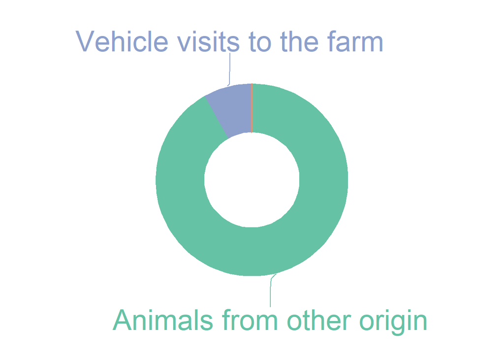

(b) BVD

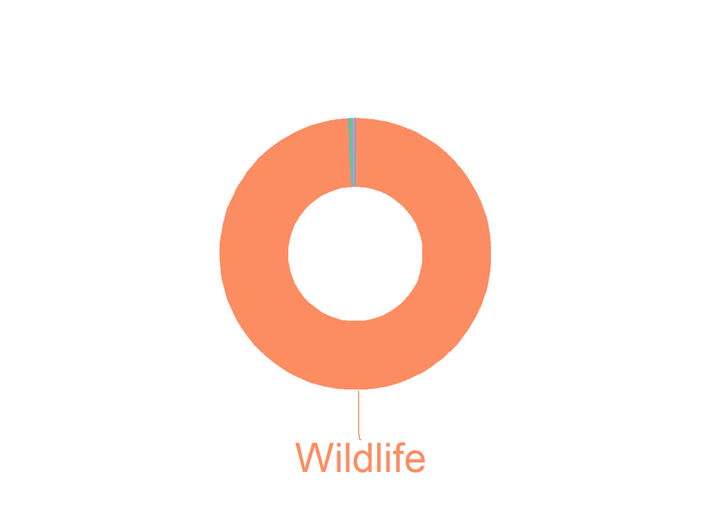

(c) TB

Figure 1.2: Risk of disease entry by pathway

## **Infectious Bovine Rhinotracheitis (IBR)**

### Current risk

Annual risk of IBR entry in the farm: **1.57%** (0.993-2.36%)

By pathway:

- Vehicle visits to the farm: **0.827%** (0.272-1.62%)
- Animals from other origin: **0.742%** (0.641-0.847%)
- People visits to the farm: **0.00468%** (0.00152-0.00954%)

### Risk reduction of biosecurity measures

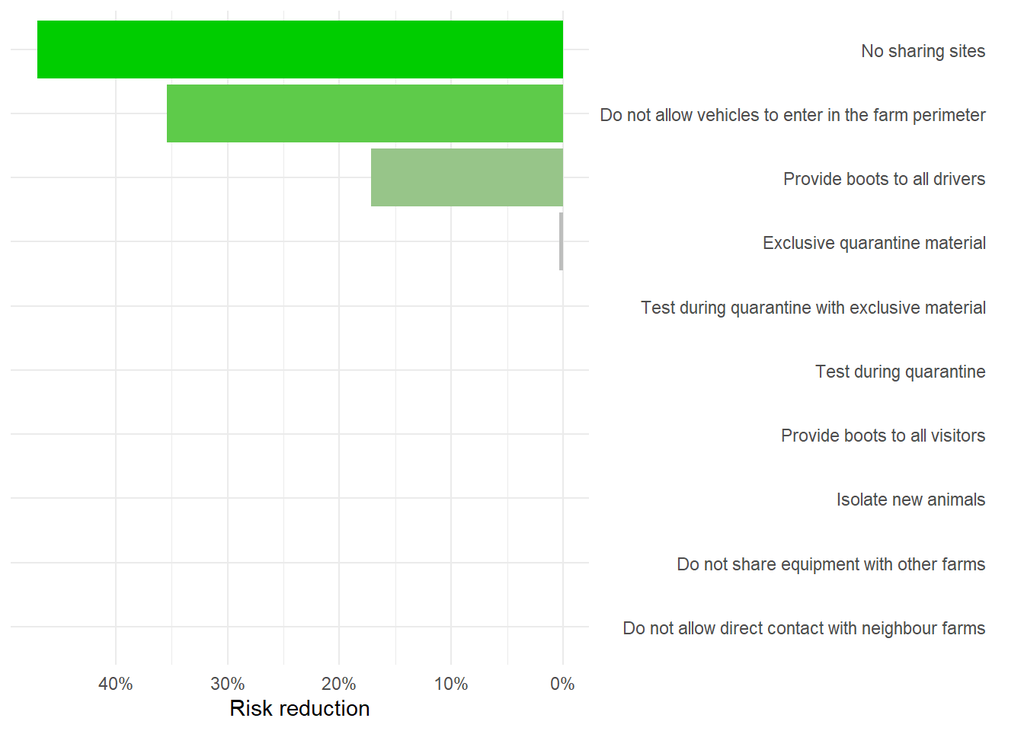

## **Bovine viral diarrhea (BVD)**

### Current risk

Annual risk of BVD entry in the farm: **13%** (8.68-16.5%)

By pathway:

- Animals from other origin: **12%** (7.72-15.5%)
- Vehicle visits to the farm: **1.06%** (0.317-2.28%)
- People visits to the farm: **0.00864%** (0.00237-0.0209%)

### Risk reduction of biosecurity measures

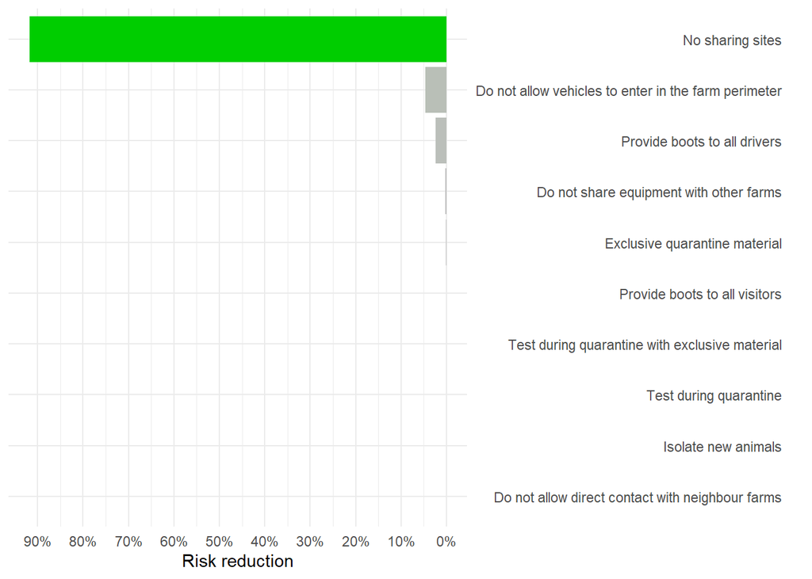

## **Bovine Tuberculosis (TB)**

### Current risk

By pathway:

- Wildlife: **0.307%** (0.132-0.687%)
- Animals from other origin: **0.00178%** (0.00135-0.00231%)
- Vehicle visits to the farm: **0.000797%** (5.19e-05-0.0041%)
- People visits to the farm: **4.76e-06%** (2.94e-07-2.37e-05%)

### Risk reduction of biosecurity measures

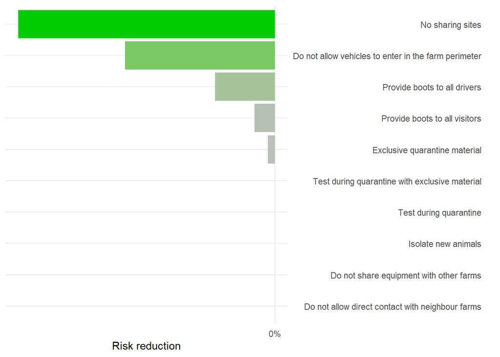

# 🐄 Description of the farm

## Farm information

**Location:** Cataluña, Spain

**Farm type:** Beef cattle, NA

**Cattle cens:**

- 28 Calves ( <8 m)
- 6 Heifers (8 - 24 m)
- 45 Adult cows (>24 m)
- 1 Bulls

**Other animals in the farm:**

- **Direct contact with cattle:**
- **No direct contact with cattle:**

**Neighbours**: No cattle farms within a 1-2km radious (negligible risk)

## Farm vehicles

| veh_id | Size | Shared | Cleaning |
| --- | --- | --- | --- |
| gris (a) | 8m2 | No | From time to time |

## Visits

### People entering the barn

| Visit | Type | Frequency | Boots | Equipment | Risk |
| --- | --- | --- | --- | --- | --- |
| vet | External veterinarians | 4 | Always used in other farms, unk cleaned and disinfected | Always used in other farms, unk cleaned and disinfected | IBR: 0.00468%, BVD: 0.00864%, TB: 4.76e-06% |

### Vehicles entering the farm perimeter

| Visit | Type | Frequency | Driver | Risk |
| --- | --- | --- | --- | --- |
| terneros | Calf transport vehicle | 6 | Contacts farm animals, boots always used in other farms, unk cleaned and disinfected | IBR: 0.82%, BVD: 1.06%, TB: 0.000797% |
| pinso_palla | Feed vehicle | 12 | - | IBR: 0.00267%, BVD: 0.000549%, TB: 1.64e-07% |

# 🚚 Movements

Animal movements in the last 12 months

[output not shown]

### Health status and tests in origin

| mov_id | Pathogen | Health status in origin | Test in origin |  |
| --- | --- | --- | --- | --- |
| pasto_invierno | BVD | Unknown | none |  |
|  | IBR |  |  |  |
|  | TB |  |  | T3 (Officially free) |

### Quarantine

#### Characteristics

*No quarantine*

# 🐗 Wildlife

**Wildlife:** IBR: -, BVD: -, TB: 0.307%

- Outdoors grazing: Outdoors grazing, no complete perimeter fence (electric, simple) (IBR: -, BVD: -, TB: 0.0781%)
- Pasture (trashumance): No pastures

### Farm water points

| Risk point | Mud/Organic | Risk |
| --- | --- | --- |
| 100% High waterer (>90cm) | 0% | 0.0% (0.0-0.0%) |
| 100% River | 100% | 0.034% (0.0043-0.13%) |
| 100% Stream (seasonal flow) | 100% | 0.035% (0.0048-0.15%) |

### Pasture water points

*No pasture water points*

# Comments

*No survey comments*

# Technical Annex

- Simulation date: 2025-12-02 13:12:33
- Script unification date: 2025-12-02 13:09:10
- Repository: https://github.com/NataliaCiria/biosecurity_model.git
- Last commit: 227e16341bdba07ddd3522e39e26e8cdd06448a3
- Last commit date: 2025-12-01 23:54:29
- user_id:
- farm_id: bc11_v2
- Risk timeframe: 360 days
- Calculate all summaries: FALSE
- Automatic what-if scenarios: TRUE
- Analyse model sensitivity: FALSE
- Farm biosecurity survey: _v4_3_ciria 2015-07-16
- Movements surveys:
  - v4_1_ciria ( 1 ): pasto_invierno